# Modelling Cognitive Decline

created: 4 July 2018

## Mild Cognitive Impairment (MCI)

- classification typically used in prospective studies of older adults
- identify participants who are more likely to receive proximal diagnosis of dementia
- increasingly used as a **clinical diagnosis**

## Diagnostic criteria

- sex- and age-adjusted z-scores from cognitive test/s
- typically rely on a threshold; e.g one or more tests with \(z < 1.5\)
- false positive rate vulnerable to inflation
  - within-subject variation
  - multiple testing
  - population heterogeneity

## Change of states

- prodromal phase of dementia indicating developing pathological state?
- classification/diagnosis only accurate if *acyclic*
  - no recovery, only progression to dementia

## Improving classification/diagnosis

- reducing error will improve power of studies
- proposed solutions to date -
  - “raise the bar”
    - more stringent thresholds
    - differentiating between scores on cognitive domains (which may not be orthogonal)
  - state-space models?

## Proposed solution

- wish list:
  - single-subject or multiple-subject designs
  - single-test or multiple-test designs (*that control Type 1 error!*)
  - *must model a change from cognitively healthy to cognitive decline state*

## Piece-wise linear regression?

- assume cognitively normal at beginning of study
- allow possibility of cognitive decline at some point
- fit two slopes to data
- find **break-point** that best fits
  1. **data**
  2. **a process of transition from healthy to cognitive decline!**

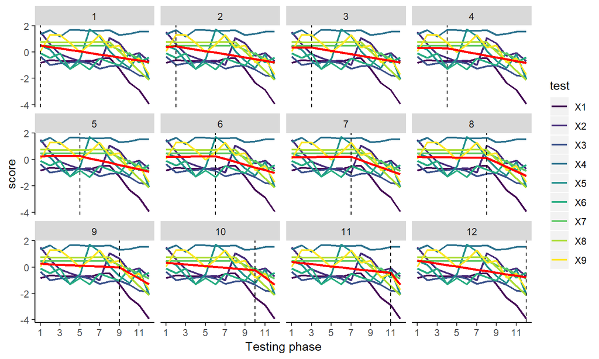

```r
loss <- function(i){
  p$cp0 <- ifelse(p$tau > i, p$tau - i, 0)
  deviance(lmer(score ~ tau + cp0 + (tau + cp0|test), data = p))
}

which.min(sapply(unique(p$tau), loss))
```

```
## [1] 8
```

## Problems

Fitting the data is easy (OLS, maximum-likelihood), but maximising \(p(y|m_i)\) is not guaranteed to find the break-point that marks the beginning of cognitive decline (if cognitive decline is even present).

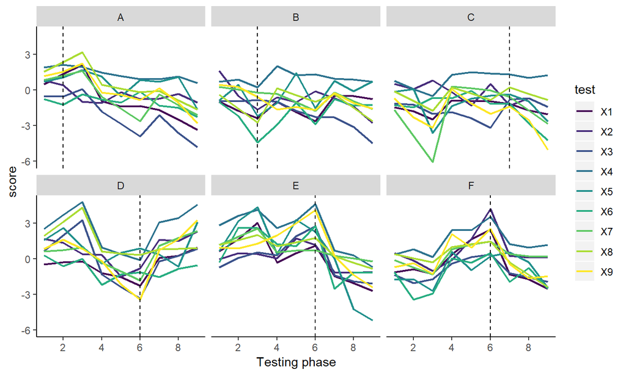

## Modelling transition

We’re not really interested in finding the model that is *best explained by* the data, we’re really interested in finding the model that *best explains* the data **if** the data are explained by cognitive decline.

Ideally this model will have \(\beta_1 \approx 0\) when the subject is in a healthy state and \(\beta_2 + \beta_1 \leq 0\) when the subject is experiencing cognitive decline.

We seek to maximise \(Pr(m_i|y)\) where \(Pr(m_i|y) = \frac{Pr(y|m_i)Pr(m_i)}{\sum_{j=1}^{m} Pr(y|m_j)Pr(m_j)}\), \(\Pr(y|m_i)\) is the likelihood and \(Pr(m_i)\) is a prior probability that represents our beliefs about \(\beta_{1i}, \beta_{2i}\).

```
##       tau.lwr     tau.upr     cp.lwr      cp.upr cp id cog_dec
## 1 -0.44079740 -0.17344170 -1.3232923 -0.04511513  8  A   FALSE
## 2 -0.17779396  0.07731547 -1.2598244  0.31298644  8  B   FALSE
## 3 -0.04520393  0.24839178 -1.4307912 -0.25496408  7  C    TRUE
## 4 -1.80368207  0.56109928 -0.6196785  1.90261981  2  D   FALSE
## 5 -0.07760293  0.26844304 -2.0661915 -0.87235887  6  E    TRUE
## 6  0.36600115  0.62563762 -1.7823792 -1.09317589  6  F   FALSE
```

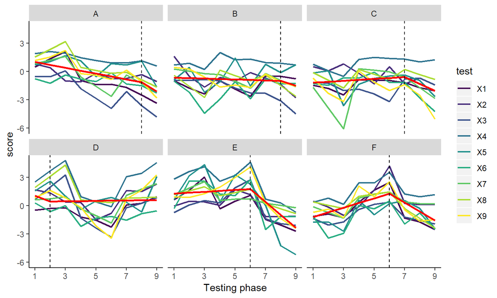